# Act-Learn Sequence

Kyle MacDonald

September 30, 2015

This script analyzes data from an experiment testing the effectiveness of different sequences of active vs. passive training in a category learning task.

In this experiment, we only ran the rule-based (easier, 1-D category structure). The hypothesis is that getting a block of receptive data will make participants more effective active learners, boosting their accuracy on test trials.

## Load data

Sequence data and Yoked data.

Some munging, so we can merge.

Now merge.

## Exclusionary criteria

Overall performance (averaged across blocks) was more than three standard deviations below the mean of their group.

Map means and sd to variables

Flag subject means that are +/- 3sd

```
## Source: local data frame [5 x 3]
## Groups: condition [?]
##
##          condition include   n()
##              (chr)   (chr) (int)
## 1           active include    94
## 2 active_receptive include    29
## 3        receptive include    54
## 4 receptive_active include    23
## 5            yoked include    53
```

## Remove participants who did not understand the task

## Descriptives

| condition | order | mean_exp_length | sd_exp_length | category_type | count |
| --- | --- | --- | --- | --- | --- |
| active | order1 | 9.213806 | 4.0163403 | information-integration | 8 |
| active | order1 | 9.213806 | 4.0163403 | rule-based | 46 |
| active | order2 | 11.089671 | 5.1867785 | information-integration | 9 |
| active | order2 | 11.089671 | 5.1867785 | rule-based | 5 |
| active_receptive | order1 | 7.680843 | 5.1584244 | information-integration | 0 |
| active_receptive | order1 | 7.680843 | 5.1584244 | rule-based | 14 |
| active_receptive | order2 | 5.856587 | 1.4656123 | information-integration | 0 |
| active_receptive | order2 | 5.856587 | 1.4656123 | rule-based | 12 |
| receptive | order1 | 4.237450 | 3.3753525 | information-integration | 5 |
| receptive | order1 | 4.237450 | 3.3753525 | rule-based | 9 |
| receptive | order2 | 3.032589 | 0.5996937 | information-integration | 12 |
| receptive | order2 | 3.032589 | 0.5996937 | rule-based | 6 |
| receptive_active | order1 | 6.037413 | 2.0833147 | information-integration | 0 |
| receptive_active | order1 | 6.037413 | 2.0833147 | rule-based | 17 |
| receptive_active | order2 | 4.374879 | 0.8707745 | information-integration | 0 |
| receptive_active | order2 | 4.374879 | 0.8707745 | rule-based | 4 |
| yoked | order1 | 6.221475 | 4.8283435 | information-integration | 7 |
| yoked | order1 | 6.221475 | 4.8283435 | rule-based | 16 |
| yoked | order2 | 6.270354 | 4.7463234 | information-integration | 7 |
| yoked | order2 | 6.270354 | 4.7463234 | rule-based | 3 |

Histogram of length of experiment split by condition

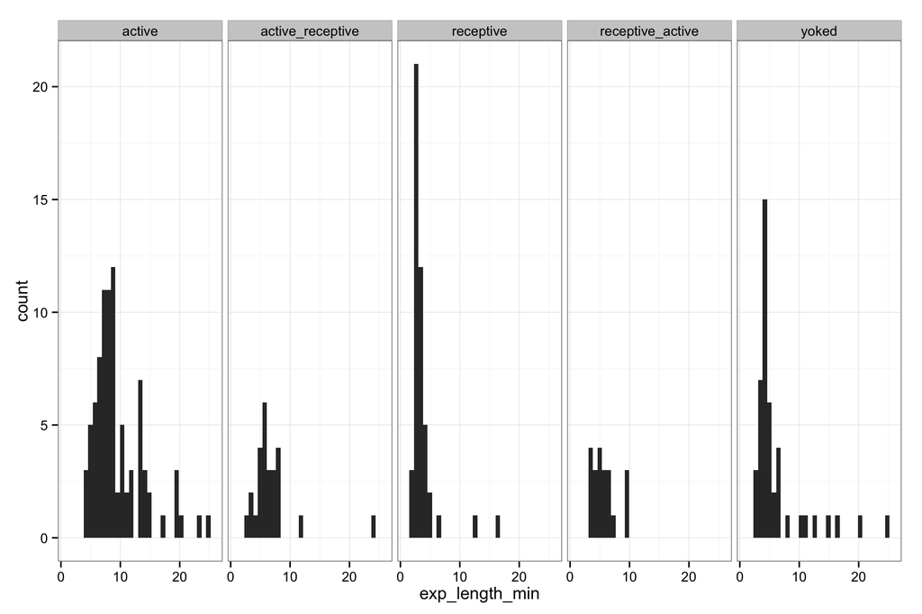

## Overall accuracy analysis

Get mean accuracy for each condition and category type

Plot.

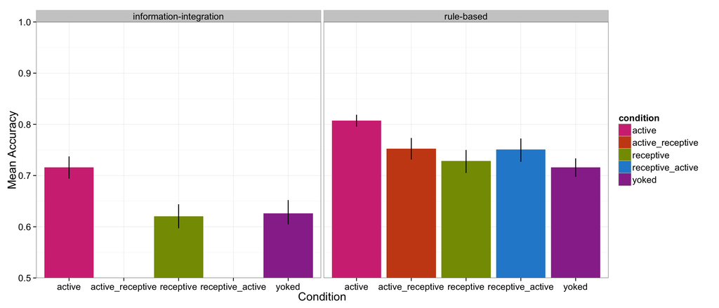

## Accuracy by block analysis

Next, we analyze accuracy across the two blocks.

Plot.

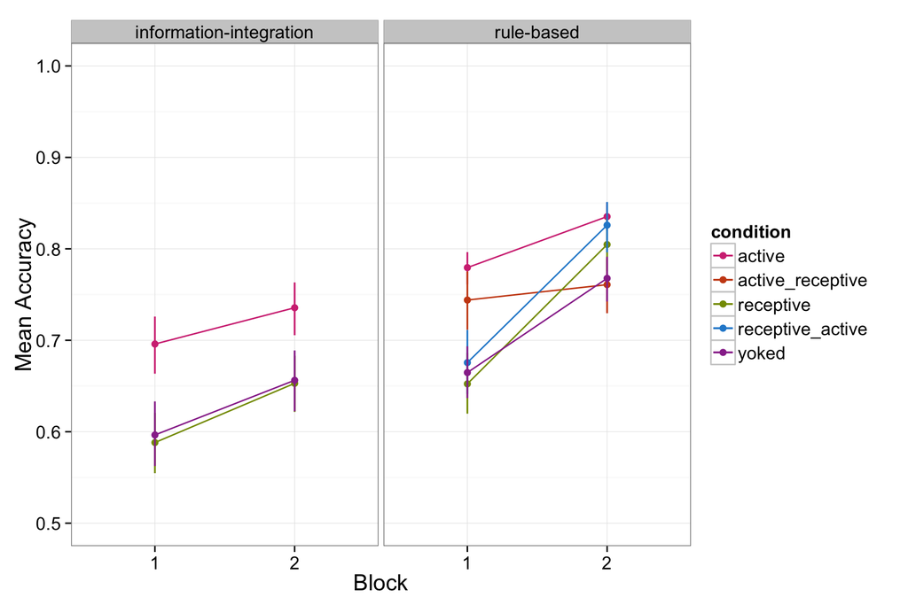

The block analysis suggests some effect of order on active learning. Receptive-first learners appear to be more accurate after their block of active learning (block 2) compared to Active-first (block 1).

But, the effect is not large enough to overcome the overall active advantage that shows up in block 1 for the Active-first learners.

## Accuracy by block and order

Order here refers to whether size or angle was the category dimension.

- Order 1 = Size
- Order 2 = Angle

Plot accuracy over blocks

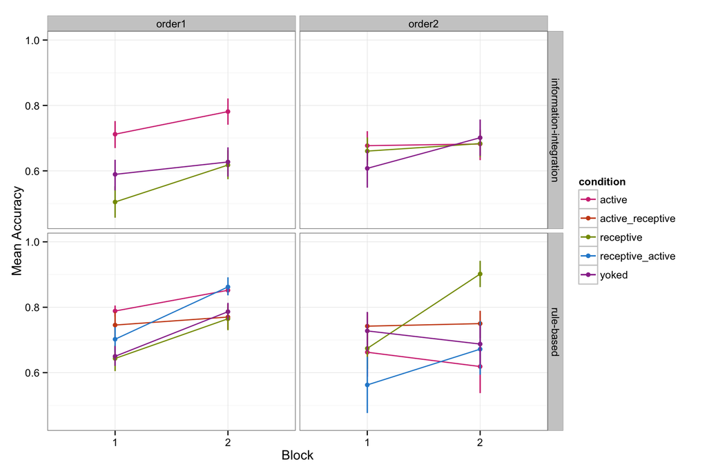

Order 1 (Size) looks like what we predicted: A small boost for Receptive-first learners.

## Evidence selection analysis (active learning)

Analyze the average distance of participants’ samples from the optimal decision boundary.

Rotate, so orientation and radius are on the same dimension.

- dim of interest = dimension with category boundary
- other dim = dimension that does not contain the category boundary

Plot group level sampling behavior.

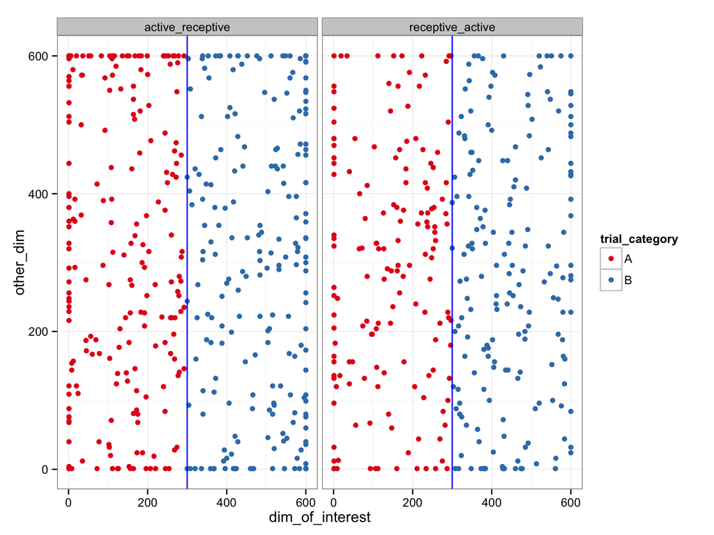

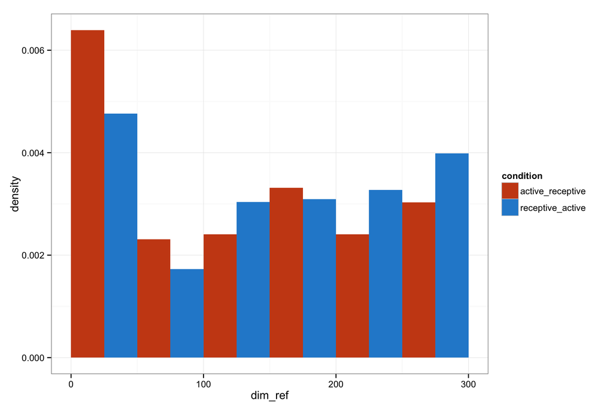

Plot individual participant sampling behavior

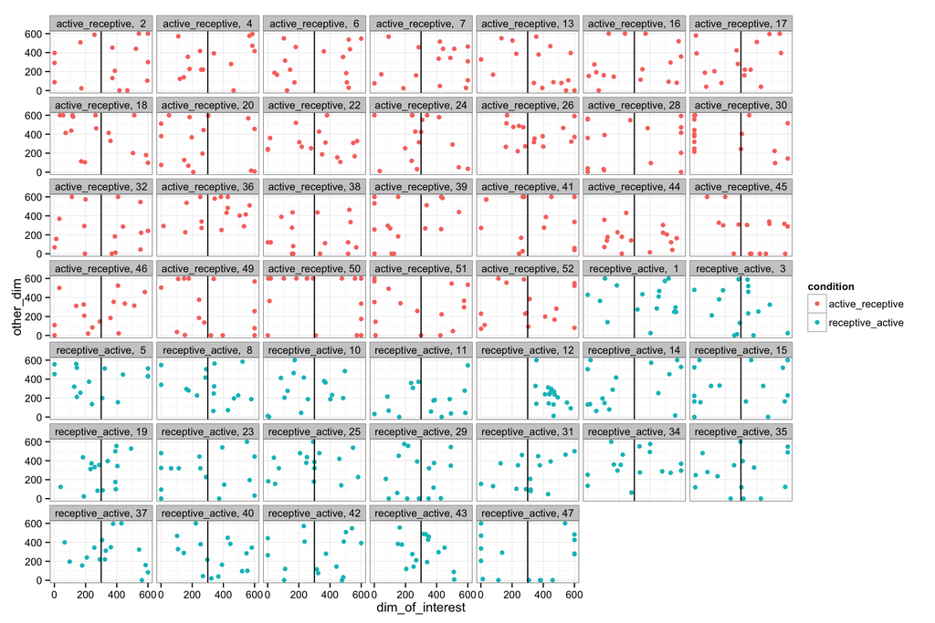

Get distance from optimal decision boundary for each sample.

Now get the average distance across subjects

Plot.

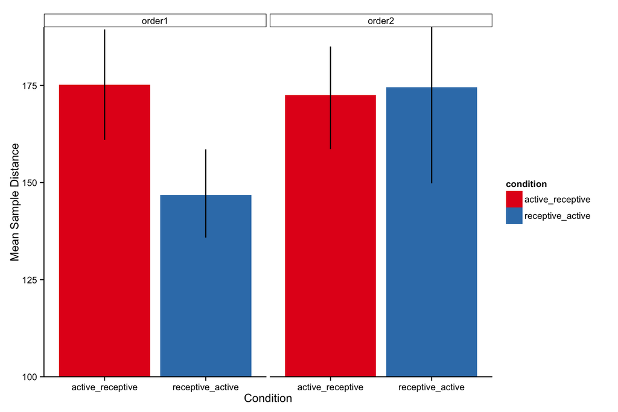

Active learning is better after getting a block of receptive learning trials. Some evidence that getting receptive-first boosted active learning.

## Relationship between sampling and test

Get the mean sample distance and accuracy for each participant.

Plot

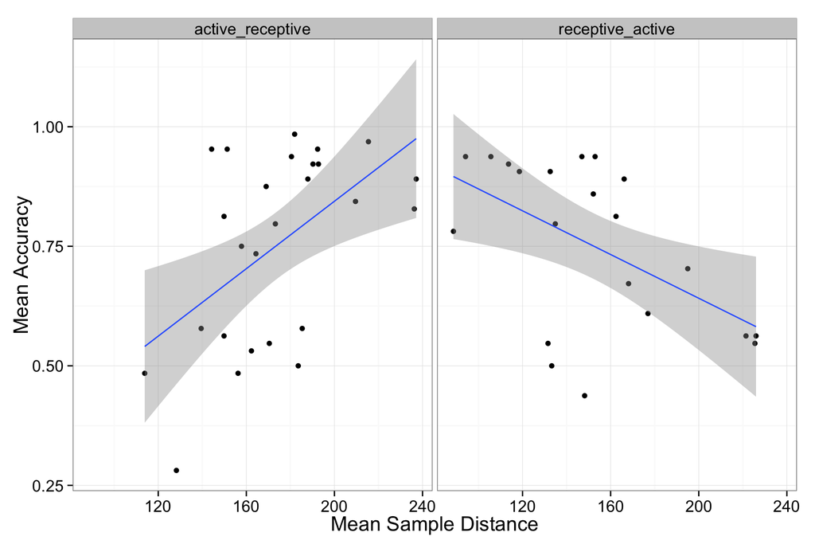

## Individual accuracy across blocks: consistency analysis

Plot.

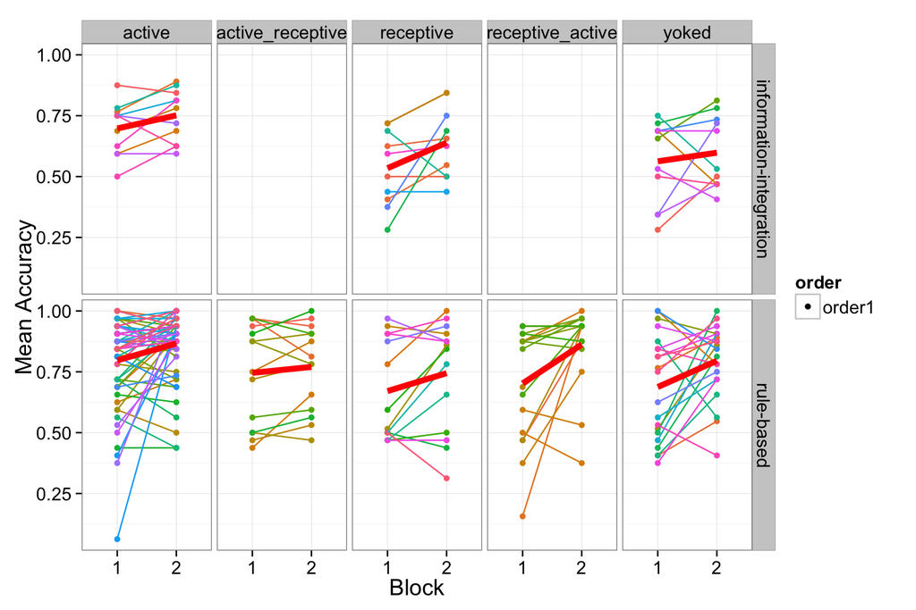

Not totally sure what to make of this. But there is a different overall pattern of accuracy performance across blocks. Active-first learners have smaller slope compared to Receptive-first learners.

There are a couple of participants doing weird things – huge drop in accuracy in block 2, but show up in both conditions.

Maybe there are some other analyses to do at the individual participant level?

## Statistics

t.test testing difference in accuracy on test trials between active first and receptive first learning conditions.

```
##
##  Two Sample t-test
##
## data:  mean_accuracy by condition
## t = 0.029977, df = 45, p-value = 0.9762
## alternative hypothesis: true difference in means is not equal to 0
## 95 percent confidence interval:
##  -0.1098578  0.1131774
## sample estimates:
## mean in group active_receptive mean in group receptive_active
##                      0.7524038                      0.7507440
```

Overall accuracy scores of the two groups are not different.

```
##
##  Two Sample t-test
##
## data:  mean_accuracy_active_block by condition
## t = -1.2546, df = 45, p-value = 0.2161
## alternative hypothesis: true difference in means is not equal to 0
## 95 percent confidence interval:
##  -0.21338197  0.04957703
## sample estimates:
## mean in group active_receptive mean in group receptive_active
##                      0.7439904                      0.8258929
```

## Models

### Accuracy on the trial-level based on condition and block

Does condition and block predict accuracy on test trials?

```
## Generalized linear mixed model fit by maximum likelihood (Laplace
##   Approximation) [glmerMod]
##  Family: binomial  ( logit )
## Formula: correct ~ condition * block + (1 | subids)
##    Data: filter(df, category_type == "rule-based", trial_type == "test")
##
##      AIC      BIC   logLik deviance df.resid
##  11265.7  11346.5  -5621.9  11243.7    11381
##
## Scaled residuals:
##     Min      1Q  Median      3Q     Max
## -5.4161  0.2052  0.3587  0.5808  1.4517
##
## Random effects:
##  Groups Name        Variance Std.Dev.
##  subids (Intercept) 0.9848   0.9924
## Number of obs: 11392, groups:  subids, 132
##
## Fixed effects:
##                                 Estimate Std. Error z value Pr(>|z|)
## (Intercept)                       1.1785     0.1579   7.464 8.38e-14 ***
## conditionactive_receptive        -0.1700     0.2437  -0.698 0.485398
## conditionreceptive               -1.1871     0.2608  -4.551 5.33e-06 ***
## conditionreceptive_active        -1.1913     0.2654  -4.488 7.19e-06 ***
## conditionyoked                   -0.6311     0.2184  -2.890 0.003850 **
## block                             0.4058     0.0804   5.047 4.50e-07 ***
## conditionactive_receptive:block  -0.3015     0.1456  -2.071 0.038324 *
## conditionreceptive:block          0.5130     0.1511   3.396 0.000683 ***
## conditionreceptive_active:block   0.5191     0.1603   3.239 0.001199 **
## conditionyoked:block              0.1519     0.1254   1.212 0.225669
## ---
## Signif. codes:  0 '***' 0.001 '**' 0.01 '*' 0.05 '.' 0.1 ' ' 1
##
## Correlation of Fixed Effects:
##             (Intr) cndtnc_ cndtnr cndtnr_ cndtny block  cndtnc_: cndtnr:
## cndtnctv_rc -0.465
## condtnrcptv -0.485  0.321
## cndtnrcptv_ -0.442  0.265   0.308
## conditinykd -0.548  0.369   0.392  0.339
## block       -0.733  0.476   0.444  0.436   0.531
## cndtnctv_r:  0.405 -0.883  -0.245 -0.241  -0.293 -0.552
## cndtnrcptv:  0.391 -0.252  -0.821 -0.235  -0.280 -0.531  0.293
## cndtnrcpt_:  0.369 -0.240  -0.225 -0.847  -0.269 -0.501  0.277    0.267
## cndtnykd:bl  0.471 -0.304  -0.284 -0.281  -0.830 -0.641  0.354    0.341
##             cndtnr_:
## cndtnctv_rc
## condtnrcptv
## cndtnrcptv_
## conditinykd
## block
## cndtnctv_r:
## cndtnrcptv:
## cndtnrcpt_:
## cndtnykd:bl  0.321
## convergence code: 0
## Model failed to converge with max|grad| = 0.00103321 (tol = 0.001, component 1)
```

Reliable interaction between condition and block. Receptive-first learners perform better on the second block of test trials than Active-first learners.

But overall, the two groups are not different from one another. How to interpret?

### Accuracy based on sampling behavior and condition

Does mean accuracy depend on sampling behavior and condition?

```
##
## Call:
## lm(formula = mean_accuracy ~ mean_samp_dist * condition, data = ss_all)
##
## Residuals:
##      Min       1Q   Median       3Q      Max
## -0.32224 -0.09478  0.04725  0.10972  0.30555
##
## Coefficients:
##                                           Estimate Std. Error t value
## (Intercept)                               0.138897   0.192067   0.723
## mean_samp_dist                            0.003526   0.001088   3.240
## conditionreceptive_active                 0.959532   0.239480   4.007
## mean_samp_dist:conditionreceptive_active -0.005812   0.001419  -4.096
##                                          Pr(>|t|)
## (Intercept)                              0.473489
## mean_samp_dist                           0.002310 **
## conditionreceptive_active                0.000240 ***
## mean_samp_dist:conditionreceptive_active 0.000182 ***
## ---
## Signif. codes:  0 '***' 0.001 '**' 0.01 '*' 0.05 '.' 0.1 ' ' 1
##
## Residual standard error: 0.1637 on 43 degrees of freedom
## Multiple R-squared:  0.2809, Adjusted R-squared:  0.2308
## F-statistic:   5.6 on 3 and 43 DF,  p-value: 0.002478
```

Reliable interaction between mean sample distance and condition. If you get Receptive-first, then better sampling predicts better test, but not if you get Active-first.

### Sampling behavior based on condition

Which condition is “better” at sampling?

```
## Linear mixed model fit by REML ['lmerMod']
## Formula: samp_dist_odb ~ condition + (1 | subids)
##    Data: df_sampling
##
## REML criterion at convergence: 9011.7
##
## Scaled residuals:
##      Min       1Q   Median       3Q      Max
## -2.17242 -0.84586 -0.03882  0.96184  1.81050
##
## Random effects:
##  Groups   Name        Variance Std.Dev.
##  subids   (Intercept)  652.3   25.54
##  Residual             9100.6   95.40
## Number of obs: 752, groups:  subids, 47
##
## Fixed effects:
##                           Estimate Std. Error t value
## (Intercept)                173.976      6.853  25.386
## conditionreceptive_active  -21.854     10.252  -2.132
##
## Correlation of Fixed Effects:
##             (Intr)
## cndtnrcptv_ -0.668
```

Receptive-first participants are better at sampling than active first participants.